# Schizophrenia Worldwide

Project “Dependence of schizophrenia disorder on different world development and healthcare systems indicators”

Preparing the data:

Loading libraries

```r
library(ggplot2)
library(olsrr)
library(dplyr)
library(lmtest)
library(mctest)
library(GGally)
library(MASS)
library(stats)
```

Loading datasets:

```r
mhd <- read.csv('MentalHealthDisorders.csv')
wdi <- read.csv('WDIData_T.csv')
beds_mhh_p100t <- read.csv('beds_in_mental_health_hospitals_per_100thousands.csv')
beds_mhg_p100t <- read.csv('beds_for_mh_in_general_hospital_per100thousand_2019.csv')
psycho_p100t <- read.csv('psychologists_in_mental_health_per_100thousands.csv')
psychi_p100t <- read.csv('psychiatrists_in_mental_health.csv')
sw_p100t <- read.csv('social_workers_in_mental_health_per_100thousands.csv')
```

Select only 2017 year for the research from dataset with different mental disorders rates worldwide:

```r
mhd <- mhd[0:6468, ]
mhd2  <- mhd[mhd$Year == 2017  , ]
head(mhd2)
```

```
##     index               Entity Code Year Schizophrenia.... Bipolar.disorder....
## 28     27          Afghanistan  AFG 2017          0.166158             0.708089
## 56     55              Albania  ALB 2017          0.201025              0.70448
## 84     83              Algeria  DZA 2017          0.197913             0.818687
## 112   111       American Samoa  ASM 2017          0.248557             0.468305
## 140   139 Andean Latin America      2017          0.201471             0.881737
## 168   167              Andorra  AND 2017          0.263512             0.963331
##     Eating.disorders.... Anxiety.disorders.... Drug.use.disorders....
## 28              0.107142              4.882481               2.473934
## 56              0.174046              3.385245               0.517614
## 84              0.213612              5.065876               1.717218
## 112             0.177808              3.315834               0.772801
## 140             0.355475              4.267738               0.661481
## 168             0.644559              5.305375               0.910066
##     Depression.... Alcohol.use.disorders....
## 28        4.136347                  0.661217
## 56        2.208414                  1.837955
## 84        3.661094                  0.665191
## 112       2.939668                  1.142277
## 140       2.610385                  1.533573
## 168       3.729532                  1.256050
```

The entire dataset with different World Development indicator contains more than 1400 indicators. For initial hypothesis about factors which can influence to the schizophrenia rate is the indicators should be from the following groups: 1. Economic factors, such as GDP, healthcare system expenditures 2. World development indicators. such as education indicators, urbanization, social factors, environmental indicators 3. Demographic indicators 4. HealthCare System indicators

At the first step it was decided to select these variables by 3 ways: 1. At first, some factors were selected to check by decision to understand is there any significant correlation between schizophrenia and such factors as: - GPD per capita - Current health expenditure per capita - Duration of education (primary and secondary) - Urban population (number and in % of total)

2. Secondly, for checking independent and significant variables the stepwise method was implemented for World Development Indicator dataset contained of more than 1400 indicators worldwide. By this method the next factors were selected:
- Primary school starting age (years)
- Rural population
- Birth rate, crude (per 1,000 people)
- People using at least basic drinking water services (% of population)
- PM2.5 air pollution, population exposed to levels exceeding WHO guideline value (% of total)

Therefore, from dataset with World Development Indicators were selected next variables:

```r
head(wdi$Year)
```

```
## [1] 1960 1960 1960 1960 1960 1960
```

```r
wdi2 = wdi[wdi$Year == 2017, ]
wdi_codes <- c('NY.GDP.PCAP.CD',
'SH.XPD.CHEX.PC.CD',
'SE.PRM.DURS',
'SE.SEC.DURS',
'SP.URB.TOTL.IN.ZS',
'SE.PRM.AGES',
'EN.ATM.PM25.MC.ZS',
'SP.RUR.TOTL',
'SH.H2O.BASW.ZS',
'SP.DYN.CBRT.IN',
'SP.URB.TOTL')
for (col in wdi_codes){
  print(paste(col, ':', wdi2[wdi2$IndicatorCode == col, ]$IndicatorName[3]))
}
```

```
## [1] "NY.GDP.PCAP.CD : GDP per capita (current US$)"
## [1] "SH.XPD.CHEX.PC.CD : Current health expenditure per capita (current US$)"
## [1] "SE.PRM.DURS : Primary education, duration (years)"
## [1] "SE.SEC.DURS : Secondary education, duration (years)"
## [1] "SP.URB.TOTL.IN.ZS : Urban population (% of total population)"
## [1] "SE.PRM.AGES : Primary school starting age (years)"
## [1] "EN.ATM.PM25.MC.ZS : PM2.5 air pollution, population exposed to levels exceeding WHO guideline value (% of total)"
## [1] "SP.RUR.TOTL : Rural population"
## [1] "SH.H2O.BASW.ZS : People using at least basic drinking water services (% of population)"
## [1] "SP.DYN.CBRT.IN : Birth rate, crude (per 1,000 people)"
## [1] "SP.URB.TOTL : Urban population"
```

3. In addition, the healthcare systems indicators were selected from official WHO datasets (https://www.who.int/data/gho/data/indicators) :
- Psychiatrists working in mental health sector (per 100,000)
- Psychologists working in mental health sector (per 100,000)
- Beds for mental health in general hospitals (per 100,000)
- Beds in mental hospitals (per 100,000)

```r
Code1 = wdi_codes[1]
df_wdi = wdi2[wdi2$IndicatorCode == Code1, ][c('CountryCode', 'Year', 'Value')]
colnames(df_wdi) <- c( 'CountryCode', 'Year', Code1)
for (Code2 in wdi_codes[2:length(wdi_codes)])
{
  df2 = wdi2[wdi2$IndicatorCode == Code2, ][c('CountryCode', 'Year', 'Value')]
  colnames(df2) <- c('CountryCode', 'Year', Code2)
  df_wdi <- merge(x = df_wdi, y = df2, by = c('CountryCode', 'Year'), all = TRUE)
}
head(df_wdi)
```

```
##   CountryCode Year NY.GDP.PCAP.CD SH.XPD.CHEX.PC.CD SE.PRM.DURS SE.SEC.DURS
## 1         ABW 2017      29007.693                NA           6           5
## 2         AFG 2017        556.302          67.12265           6           6
## 3         AGO 2017       4095.813         114.45964           6           6
## 4         ALB 2017       4531.021                NA           5           7
## 5         AND 2017      38962.880        4040.78662           6           6
## 6         ARB 2017       6102.211         345.78941           6           6
##   SP.URB.TOTL.IN.ZS SE.PRM.AGES EN.ATM.PM25.MC.ZS SP.RUR.TOTL SH.H2O.BASW.ZS
## 1          43.29300           6                NA       59750             NA
## 2          25.25000           7         100.00000    27131559       67.06462
## 3          64.83900           6         100.00000    10483867       55.84290
## 4          59.38300           6         100.00000     1167112       91.03923
## 5          88.15000           6          17.82446        9125      100.00000
## 6          58.64148          NA                NA   170355303       88.63129
##   SP.DYN.CBRT.IN SP.URB.TOTL
## 1       11.53200       45616
## 2       33.21100     9164841
## 3       41.28100    19332881
## 4       11.93400     1706345
## 5             NA       67876
## 6       25.64801   241543664
```

```r
shizo <- mhd2[c('Year','Code', 'Schizophrenia....')]
colnames(shizo) <- c('Year','CountryCode', 'Schizo')
shizo$Schizo <- as.numeric(shizo$Schizo)
df3 <- merge(x = shizo, y = df_wdi, by = c('CountryCode', 'Year'))
df3 <- na.omit(df3[ , colSums(is.na(df3))<5])

df_temp <- psychi_p100t[c('SpatialDimValueCode', 'Value')]
colnames(df_temp) <- c('CountryCode', 'psychi_p100t')
df3 <- merge(x = df3, y = df_temp, by = c('CountryCode'), all = FALSE)
df_temp <- beds_mhh_p100t[c('SpatialDimValueCode', 'Value')]
colnames(df_temp) <- c('CountryCode', 'beds_mhh_p100t')
df3 <- merge(x = df3, y = df_temp, by = c('CountryCode'),  all = FALSE)
#df3 <- merge(x = df3, y = df_wdi, by = c('CountryCode', 'Year'), all = FALSE)
df_temp <- psycho_p100t[c('SpatialDimValueCode', 'Value')]
colnames(df_temp) <- c('CountryCode', 'psycho_p100t')
df3 <- merge(x = df3, y = df_temp, by = c('CountryCode'), all = FALSE)
df_temp <- beds_mhg_p100t[c('SpatialDimValueCode', 'Value')]
colnames(df_temp) <- c('CountryCode', 'beds_mhg_p100t')
df3 <- merge(x = df3, y = df_temp, by = c('CountryCode'),  all = FALSE)
df3 <- na.omit(df3)

head(df3)
```

```
##   CountryCode Year   Schizo SE.PRM.DURS SP.URB.TOTL.IN.ZS SE.PRM.AGES
## 1         AFG 2017 0.166158           6            25.250           7
## 2         AGO 2017 0.172794           6            64.839           6
## 3         ALB 2017 0.201025           5            59.383           6
## 4         ARE 2017 0.210718           5            86.248           6
## 5         AUS 2017 0.363326           7            85.904           5
## 6         AZE 2017 0.199998           4            55.343           6
##   EN.ATM.PM25.MC.ZS SP.RUR.TOTL SH.H2O.BASW.ZS SP.DYN.CBRT.IN SP.URB.TOTL
## 1         100.00000    27131559       67.06462         33.211     9164841
## 2         100.00000    10483867       55.84290         41.281    19332881
## 3         100.00000     1167112       91.03923         11.934     1706345
## 4         100.00000     1304680       98.04551         10.456     8182523
## 5          24.89358     3467878       99.96994         12.600    21133982
## 6         100.00000     4400516       91.38574         14.600     5453517
##   psychi_p100t beds_mhh_p100t psycho_p100t beds_mhg_p100t
## 1        0.230           0.30         0.30           0.30
## 2        0.057           0.59         0.18           0.19
## 3        1.470          16.76         1.23           4.28
## 4        1.650           0.90         0.76           2.99
## 5       13.530           7.21       103.00          21.76
## 6        3.450          31.19         1.16           0.42
```

For these parameters the linear model was created and the stepwise regression procedure was launched:

```r
dependent_variable <- 'Schizo'
independent_variables <- colnames(df3[5:length(df3)])
formula <- paste(dependent_variable, "~ (", paste(independent_variables, collapse=" + "), ')')
print(formula)
```

```
## [1] "Schizo ~ ( SP.URB.TOTL.IN.ZS + SE.PRM.AGES + EN.ATM.PM25.MC.ZS + SP.RUR.TOTL + SH.H2O.BASW.ZS + SP.DYN.CBRT.IN + SP.URB.TOTL + psychi_p100t + beds_mhh_p100t + psycho_p100t + beds_mhg_p100t )"
```

```r
model <- lm(formula, data = df3)
summary(model)
```

```
##
## Call:
## lm(formula = formula, data = df3)
##
## Residuals:
##       Min        1Q    Median        3Q       Max
## -0.050033 -0.009464 -0.004318  0.012017  0.045655
##
## Coefficients:
##                     Estimate Std. Error t value Pr(>|t|)
## (Intercept)        3.661e-01  4.668e-02   7.842 6.75e-11 ***
## SP.URB.TOTL.IN.ZS  3.007e-05  1.574e-04   0.191 0.849080
## SE.PRM.AGES       -2.081e-02  5.180e-03  -4.018 0.000159 ***
## EN.ATM.PM25.MC.ZS -6.939e-04  1.148e-04  -6.044 8.94e-08 ***
## SP.RUR.TOTL        1.517e-11  4.533e-11   0.335 0.738955
## SH.H2O.BASW.ZS     4.222e-04  3.011e-04   1.402 0.165702
## SP.DYN.CBRT.IN    -8.300e-04  5.198e-04  -1.597 0.115301
## SP.URB.TOTL        1.211e-10  7.243e-11   1.672 0.099468 .
## psychi_p100t       7.685e-06  4.931e-04   0.016 0.987614
## beds_mhh_p100t     2.657e-04  1.061e-04   2.504 0.014891 *
## psycho_p100t       3.753e-04  1.091e-04   3.439 0.001040 **
## beds_mhg_p100t    -2.160e-04  1.876e-04  -1.151 0.253963
## ---
## Signif. codes:  0 '***' 0.001 '**' 0.01 '*' 0.05 '.' 0.1 ' ' 1
##
## Residual standard error: 0.01939 on 63 degrees of freedom
## Multiple R-squared:  0.805,  Adjusted R-squared:  0.7709
## F-statistic: 23.64 on 11 and 63 DF,  p-value: < 2.2e-16
```

```r
stepwise <-ols_step_both_p(model, pent = 0.1, prem = 0.3, details = FALSE)
print(stepwise$predictors)
```

```
## [1] "EN.ATM.PM25.MC.ZS" "SH.H2O.BASW.ZS"    "SE.PRM.AGES"
## [4] "psycho_p100t"      "SP.URB.TOTL"       "beds_mhh_p100t"
```

```r
dependent_variable <- 'Schizo'
independent_variables <- stepwise$predictors
for (col in independent_variables){
  print(paste(col, ':', wdi2[wdi2$IndicatorCode == col, ]$IndicatorName[3]))
}
```

```
## [1] "EN.ATM.PM25.MC.ZS : PM2.5 air pollution, population exposed to levels exceeding WHO guideline value (% of total)"
## [1] "SH.H2O.BASW.ZS : People using at least basic drinking water services (% of population)"
## [1] "SE.PRM.AGES : Primary school starting age (years)"
## [1] "psycho_p100t : NA"
## [1] "SP.URB.TOTL : Urban population"
## [1] "beds_mhh_p100t : NA"
```

```r
formula2 <- paste(dependent_variable, "~(", paste(independent_variables, collapse=" + "), ')')

print(formula2)
```

```
## [1] "Schizo ~( EN.ATM.PM25.MC.ZS + SH.H2O.BASW.ZS + SE.PRM.AGES + psycho_p100t + SP.URB.TOTL + beds_mhh_p100t )"
```

```r
model2 <- lm(formula2, data = df3)
summary(model2)
```

```
##
## Call:
## lm(formula = formula2, data = df3)
##
## Residuals:
##      Min       1Q   Median       3Q      Max
## -0.04970 -0.01034 -0.00213  0.01143  0.04622
##
## Coefficients:
##                     Estimate Std. Error t value Pr(>|t|)
## (Intercept)        3.155e-01  3.545e-02   8.899 5.13e-13 ***
## EN.ATM.PM25.MC.ZS -6.762e-04  9.705e-05  -6.968 1.62e-09 ***
## SH.H2O.BASW.ZS     8.077e-04  1.695e-04   4.765 1.03e-05 ***
## SE.PRM.AGES       -2.103e-02  4.796e-03  -4.384 4.14e-05 ***
## psycho_p100t       3.685e-04  9.446e-05   3.901 0.000222 ***
## SP.URB.TOTL        1.401e-10  3.596e-11   3.897 0.000225 ***
## beds_mhh_p100t     2.648e-04  7.556e-05   3.505 0.000813 ***
## ---
## Signif. codes:  0 '***' 0.001 '**' 0.01 '*' 0.05 '.' 0.1 ' ' 1
##
## Residual standard error: 0.0192 on 68 degrees of freedom
## Multiple R-squared:  0.7936, Adjusted R-squared:  0.7754
## F-statistic: 43.57 on 6 and 68 DF,  p-value: < 2.2e-16
```

In the result only 6 variables were selected as independent and significant: - “EN.ATM.PM25.MC.ZS : PM2.5 air pollution, population exposed to levels exceeding WHO guideline value (% of total)” - “SH.H2O.BASW.ZS : People using at least basic drinking water services (% of population)” - “SE.PRM.AGES : Primary school starting age (years)” - “psycho_p100t : Psychologists working in mental health sector (per 100,000)” - “SP.URB.TOTL : Urban population” - “beds_mhh_p100t : Beds in mental hospitals (per 100,000)”

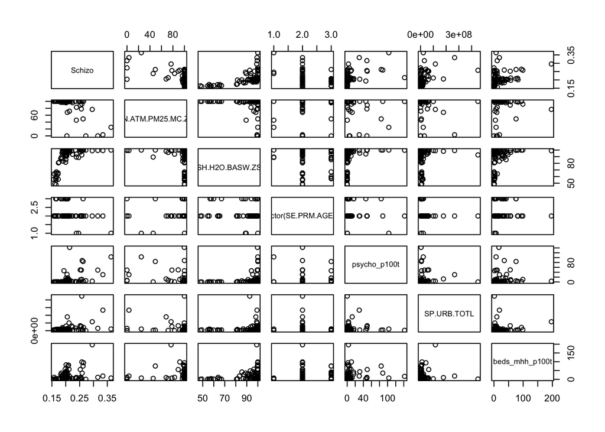

```r
#png("pairs.png", units = "in", width = 15, height = 12, res = 300)
pairs(Schizo ~ (EN.ATM.PM25.MC.ZS + SH.H2O.BASW.ZS + factor(SE.PRM.AGES) + psycho_p100t + SP.URB.TOTL + beds_mhh_p100t ), data = df3)
```

```r
#dev.off()
```

```r
model_h <- lm(Schizo ~ EN.ATM.PM25.MC.ZS + SH.H2O.BASW.ZS + SE.PRM.AGES + psycho_p100t + I(psycho_p100t^2)+ SP.URB.TOTL + beds_mhh_p100t + EN.ATM.PM25.MC.ZS:psycho_p100t, data = df3 )
summary(model_h)
```

```
##
## Call:
## lm(formula = Schizo ~ EN.ATM.PM25.MC.ZS + SH.H2O.BASW.ZS + SE.PRM.AGES +
##     psycho_p100t + I(psycho_p100t^2) + SP.URB.TOTL + beds_mhh_p100t +
##     EN.ATM.PM25.MC.ZS:psycho_p100t, data = df3)
##
## Residuals:
##       Min        1Q    Median        3Q       Max
## -0.045033 -0.010802 -0.001732  0.009417  0.043419
##
## Coefficients:
##                                  Estimate Std. Error t value Pr(>|t|)
## (Intercept)                     2.774e-01  3.455e-02   8.030 2.34e-11 ***
## EN.ATM.PM25.MC.ZS              -3.751e-04  1.139e-04  -3.293 0.001598 **
## SH.H2O.BASW.ZS                  8.437e-04  1.564e-04   5.395 9.98e-07 ***
## SE.PRM.AGES                    -2.007e-02  4.449e-03  -4.511 2.72e-05 ***
## psycho_p100t                    1.507e-03  3.095e-04   4.870 7.30e-06 ***
## I(psycho_p100t^2)              -3.053e-06  2.302e-06  -1.326 0.189319
## SP.URB.TOTL                     1.343e-10  3.257e-11   4.123 0.000107 ***
## beds_mhh_p100t                  2.492e-04  6.844e-05   3.642 0.000533 ***
## EN.ATM.PM25.MC.ZS:psycho_p100t -9.971e-06  2.817e-06  -3.540 0.000740 ***
## ---
## Signif. codes:  0 '***' 0.001 '**' 0.01 '*' 0.05 '.' 0.1 ' ' 1
##
## Residual standard error: 0.01733 on 66 degrees of freedom
## Multiple R-squared:  0.8368, Adjusted R-squared:  0.8171
## F-statistic: 42.31 on 8 and 66 DF,  p-value: < 2.2e-16
```

The testing of higher orders for different variables showed that the higher order variables gives not sifnificant influence. Therefore, it was decided not to use any higher orders in the model

```r
model_h <- lm(Schizo ~ (EN.ATM.PM25.MC.ZS + SH.H2O.BASW.ZS + SE.PRM.AGES + psycho_p100t + SP.URB.TOTL + beds_mhh_p100t)^2, data = df3 )
summary(model_h)
```

```
##
## Call:
## lm(formula = Schizo ~ (EN.ATM.PM25.MC.ZS + SH.H2O.BASW.ZS + SE.PRM.AGES +
##     psycho_p100t + SP.URB.TOTL + beds_mhh_p100t)^2, data = df3)
##
## Residuals:
##       Min        1Q    Median        3Q       Max
## -0.037702 -0.007026 -0.000084  0.004828  0.042803
##
## Coefficients:
##                                    Estimate Std. Error t value Pr(>|t|)
## (Intercept)                      -2.366e-01  4.559e-01  -0.519    0.606
## EN.ATM.PM25.MC.ZS                 1.166e-03  4.069e-03   0.287    0.776
## SH.H2O.BASW.ZS                    8.733e-03  5.682e-03   1.537    0.130
## SE.PRM.AGES                      -2.491e-03  4.769e-02  -0.052    0.959
## psycho_p100t                     -5.545e-03  9.219e-03  -0.601    0.550
## SP.URB.TOTL                       3.721e-09  5.340e-09   0.697    0.489
## beds_mhh_p100t                   -4.726e-03  3.395e-03  -1.392    0.170
## EN.ATM.PM25.MC.ZS:SH.H2O.BASW.ZS -3.952e-05  5.167e-05  -0.765    0.448
## EN.ATM.PM25.MC.ZS:SE.PRM.AGES     3.696e-04  2.899e-04   1.275    0.208
## EN.ATM.PM25.MC.ZS:psycho_p100t   -1.106e-05  6.764e-06  -1.635    0.108
## EN.ATM.PM25.MC.ZS:SP.URB.TOTL    -7.052e-13  2.120e-12  -0.333    0.741
## EN.ATM.PM25.MC.ZS:beds_mhh_p100t  1.735e-05  1.662e-05   1.044    0.301
## SH.H2O.BASW.ZS:SE.PRM.AGES       -5.871e-04  4.085e-04  -1.437    0.156
## SH.H2O.BASW.ZS:psycho_p100t       4.664e-05  8.020e-05   0.582    0.563
## SH.H2O.BASW.ZS:SP.URB.TOTL       -2.038e-11  1.735e-11  -1.174    0.246
## SH.H2O.BASW.ZS:beds_mhh_p100t     1.625e-05  2.028e-05   0.802    0.426
## SE.PRM.AGES:psycho_p100t          3.335e-04  3.578e-04   0.932    0.355
## SE.PRM.AGES:SP.URB.TOTL          -2.768e-10  7.879e-10  -0.351    0.727
## SE.PRM.AGES:beds_mhh_p100t        2.384e-04  2.936e-04   0.812    0.421
## psycho_p100t:SP.URB.TOTL          2.318e-12  6.648e-12   0.349    0.729
## psycho_p100t:beds_mhh_p100t       5.519e-06  7.404e-06   0.745    0.459
## SP.URB.TOTL:beds_mhh_p100t        6.130e-12  3.670e-12   1.670    0.101
##
## Residual standard error: 0.01718 on 53 degrees of freedom
## Multiple R-squared:  0.8711, Adjusted R-squared:  0.8201
## F-statistic: 17.06 on 21 and 53 DF,  p-value: < 2.2e-16
```

However, the testing of model with interactions showed that the interaction betwee EN.ATM.PM25.MC.ZS:psycho_p100t gives the significant value and can be kept with p-value 0.001004 after the individual t.test. The full table for indivitual t-test is given below. The result of Breucsh-Pagan test if provided bellow, which shows that p-value > 0.05. It means that the distribution of residuals follow the homoscedasticity assumption.

```r
model1 <- model2
model3 <- lm(Schizo ~ (EN.ATM.PM25.MC.ZS + SH.H2O.BASW.ZS + factor(SE.PRM.AGES) + psycho_p100t + SP.URB.TOTL + beds_mhh_p100t)^2, data = df3)
model2h <- lm(Schizo ~ (EN.ATM.PM25.MC.ZS + SH.H2O.BASW.ZS + factor(SE.PRM.AGES) + psycho_p100t +  I(psycho_p100t^2) + SP.URB.TOTL + beds_mhh_p100t + EN.ATM.PM25.MC.ZS:psycho_p100t), data = df3)
model2 <- lm(Schizo ~ (EN.ATM.PM25.MC.ZS + SH.H2O.BASW.ZS + factor(SE.PRM.AGES) + psycho_p100t  + SP.URB.TOTL + beds_mhh_p100t + EN.ATM.PM25.MC.ZS:psycho_p100t), data = df3)
bptest(model2)
```

```
##
##  studentized Breusch-Pagan test
##
## data:  model2
## BP = 11.966, df = 8, p-value = 0.1527
```

```r
summary(model2)
```

```
##
## Call:
## lm(formula = Schizo ~ (EN.ATM.PM25.MC.ZS + SH.H2O.BASW.ZS + factor(SE.PRM.AGES) +
##     psycho_p100t + SP.URB.TOTL + beds_mhh_p100t + EN.ATM.PM25.MC.ZS:psycho_p100t),
##     data = df3)
##
## Residuals:
##       Min        1Q    Median        3Q       Max
## -0.043409 -0.009767 -0.001984  0.010884  0.043904
##
## Coefficients:
##                                  Estimate Std. Error t value Pr(>|t|)
## (Intercept)                     1.895e-01  2.148e-02   8.822 9.01e-13 ***
## EN.ATM.PM25.MC.ZS              -3.856e-04  1.126e-04  -3.424 0.001064 **
## SH.H2O.BASW.ZS                  8.808e-04  1.531e-04   5.754 2.46e-07 ***
## factor(SE.PRM.AGES)6           -3.575e-02  1.131e-02  -3.160 0.002379 **
## factor(SE.PRM.AGES)7           -5.063e-02  1.177e-02  -4.303 5.70e-05 ***
## psycho_p100t                    1.132e-03  2.441e-04   4.637 1.72e-05 ***
## SP.URB.TOTL                     1.479e-10  3.284e-11   4.503 2.80e-05 ***
## beds_mhh_p100t                  2.652e-04  6.801e-05   3.900 0.000228 ***
## EN.ATM.PM25.MC.ZS:psycho_p100t -9.690e-06  2.815e-06  -3.443 0.001004 **
## ---
## Signif. codes:  0 '***' 0.001 '**' 0.01 '*' 0.05 '.' 0.1 ' ' 1
##
## Residual standard error: 0.01722 on 66 degrees of freedom
## Multiple R-squared:  0.8388, Adjusted R-squared:  0.8193
## F-statistic: 42.94 on 8 and 66 DF,  p-value: < 2.2e-16
```

```r
anova(model2h, model2h)
```

```
## Analysis of Variance Table
##
## Model 1: Schizo ~ (EN.ATM.PM25.MC.ZS + SH.H2O.BASW.ZS + factor(SE.PRM.AGES) +
##     psycho_p100t + I(psycho_p100t^2) + SP.URB.TOTL + beds_mhh_p100t +
##     EN.ATM.PM25.MC.ZS:psycho_p100t)
## Model 2: Schizo ~ (EN.ATM.PM25.MC.ZS + SH.H2O.BASW.ZS + factor(SE.PRM.AGES) +
##     psycho_p100t + I(psycho_p100t^2) + SP.URB.TOTL + beds_mhh_p100t +
##     EN.ATM.PM25.MC.ZS:psycho_p100t)
##   Res.Df      RSS Df Sum of Sq F Pr(>F)
## 1     65 0.018863
## 2     65 0.018863  0         0
```

ANOVA Test:

```r
const_model <- lm(Schizo ~ 1, data = df3)
anova(model1, model2)
```

```
## Analysis of Variance Table
##
## Model 1: Schizo ~ (EN.ATM.PM25.MC.ZS + SH.H2O.BASW.ZS + SE.PRM.AGES +
##     psycho_p100t + SP.URB.TOTL + beds_mhh_p100t)
## Model 2: Schizo ~ (EN.ATM.PM25.MC.ZS + SH.H2O.BASW.ZS + factor(SE.PRM.AGES) +
##     psycho_p100t + SP.URB.TOTL + beds_mhh_p100t + EN.ATM.PM25.MC.ZS:psycho_p100t)
##   Res.Df      RSS Df Sum of Sq      F    Pr(>F)
## 1     68 0.025071
## 2     66 0.019573  2 0.0054978 9.2693 0.0002832 ***
## ---
## Signif. codes:  0 '***' 0.001 '**' 0.01 '*' 0.05 '.' 0.1 ' ' 1
```

```r
anova(model1, model3)
```

```
## Analysis of Variance Table
##
## Model 1: Schizo ~ (EN.ATM.PM25.MC.ZS + SH.H2O.BASW.ZS + SE.PRM.AGES +
##     psycho_p100t + SP.URB.TOTL + beds_mhh_p100t)
## Model 2: Schizo ~ (EN.ATM.PM25.MC.ZS + SH.H2O.BASW.ZS + factor(SE.PRM.AGES) +
##     psycho_p100t + SP.URB.TOTL + beds_mhh_p100t)^2
##   Res.Df      RSS Df Sum of Sq      F  Pr(>F)
## 1     68 0.025071
## 2     50 0.014226 18  0.010845 2.1176 0.01906 *
## ---
## Signif. codes:  0 '***' 0.001 '**' 0.01 '*' 0.05 '.' 0.1 ' ' 1
```

```r
sqrt(mean(model2$residuals^2))
```

```
## [1] 0.01615466
```

Multiple Regression Analysis

1. Linear Assumption

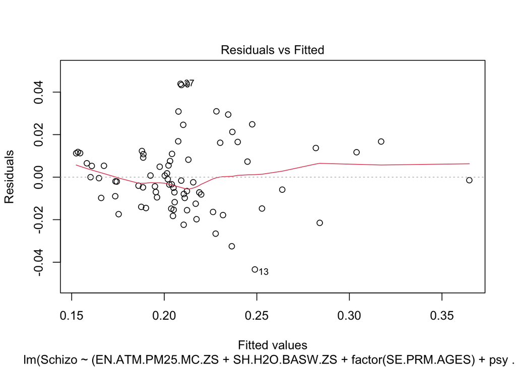

```r
#png("1.linear_assumprion.png", units = "in", width = 6, height = 4, res = 300)
plot(model2, which = 1)
```

```r
#dev.off()
```

The plot shows that linear assumption is correct for this model.

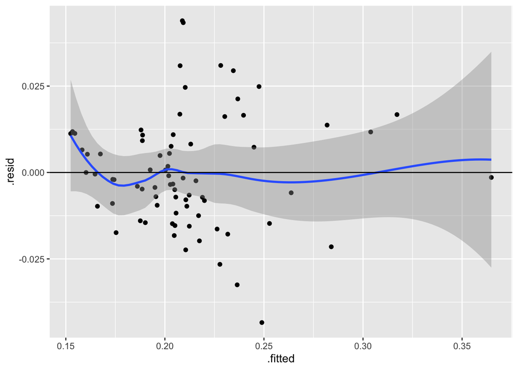

```r
#png("1.linear_assumprion2.png", units = "in", width = 6, height = 4, res = 300)
ggplot(model2, aes(x=.fitted, y=.resid)) + geom_point() + geom_smooth()+ geom_hline(yintercept = 0)
```

```r
#dev.off()
```

2. Independence Assumption

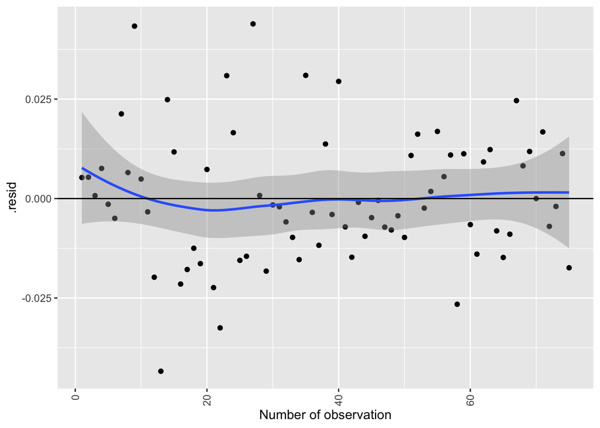

```r
#png("2.independence_assumprion.png", units = "in", width = 6, height = 4, res = 300)
ggplot(model2, aes(x=as.numeric(row.names(model.frame(model2))), y=.resid)) + geom_point() + geom_smooth()+ geom_hline(yintercept = 0) + xlab('Number of observation') +
  theme(axis.text.x = element_text(angle = 90, vjust = 0.5, hjust=1))
```

```r
#dev.off()
```

The plot shows that there is not significant dependence of residuals on the number of observation. It means that independence assumption is correct for this model.

3. Normality Assumptions

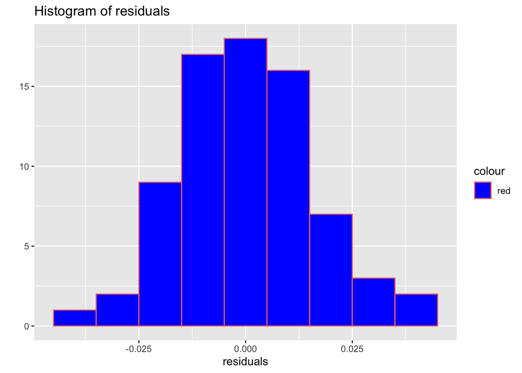

```r
#png("3.normality_assumprion.png", units = "in", width = 6, height = 4, res = 300)
qplot(residuals(model2),
geom="histogram",
binwidth = 0.01,
main = "Histogram of residuals",
xlab = "residuals", color="red",
fill=I("blue"))
```

```r
#dev.off()
```

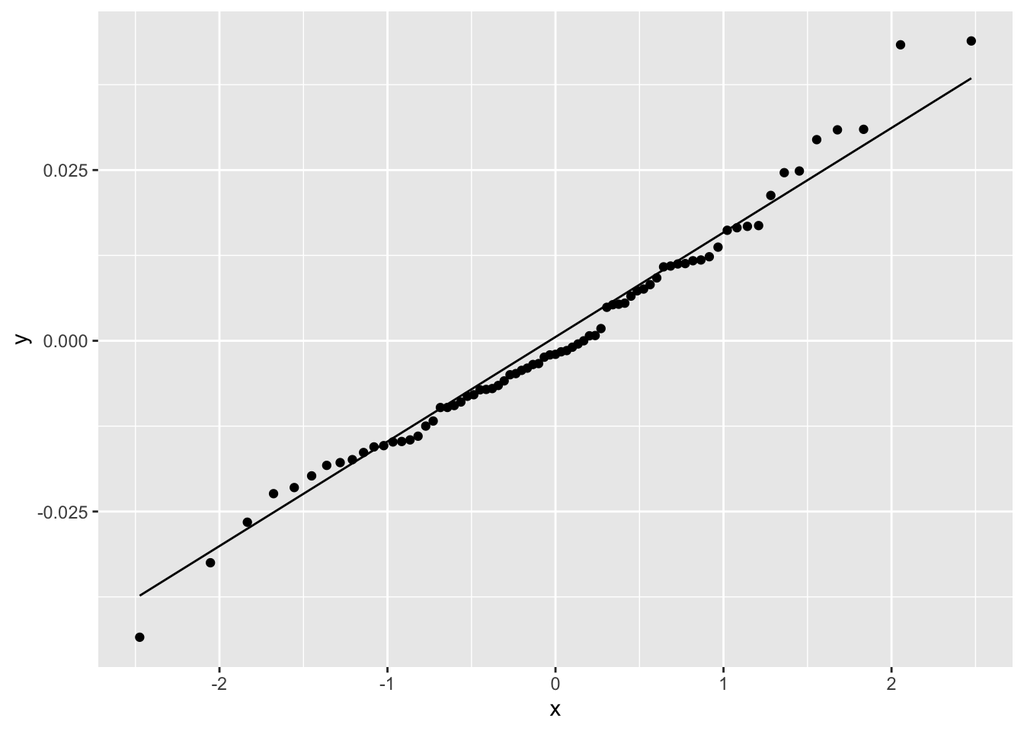

```r
#png("3.normality_assumprion_qqplot.png", units = "in", width = 6, height = 4, res = 300)
ggplot(df3, aes(sample=model2$residuals)) + stat_qq() + stat_qq_line()
```

```r
#dev.off()
```

```r
shapiro.test(residuals(model2))
```

```
##
##  Shapiro-Wilk normality test
##
## data:  residuals(model2)
## W = 0.98202, p-value = 0.3653
```

For normality assumption the normal distribution plot, QQplot and Shapiro-Wilk normality test are used. The result shows that normality assumption for the model is correct

4. Equal Vairanve Assumption

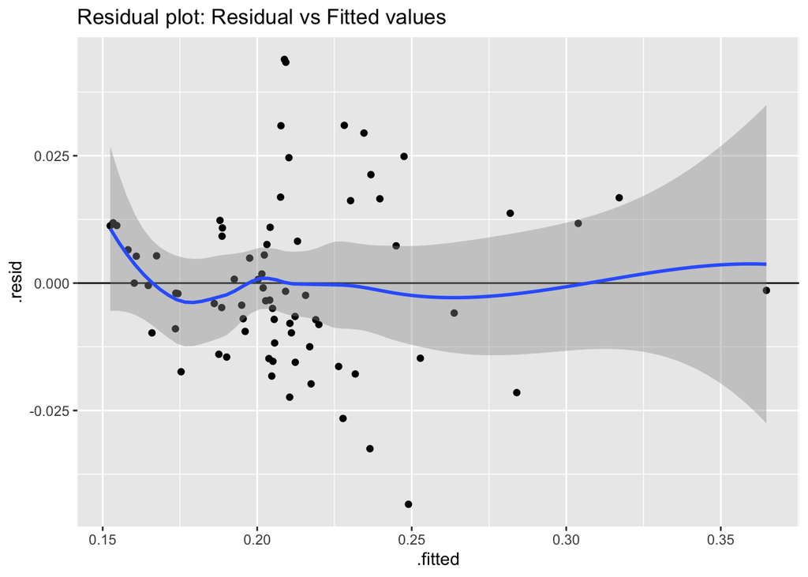

```r
#png("4.equal_variance_assumprion.png", units = "in", width = 6, height = 4, res = 300)
ggplot(model2, aes(x=.fitted, y=.resid)) +
geom_point() +
geom_hline(yintercept = 0) +
geom_smooth()+
ggtitle("Residual plot: Residual vs Fitted values")
```

```r
#dev.off()
```

```r
bptest(model2)
```

```
##
##  studentized Breusch-Pagan test
##
## data:  model2
## BP = 11.966, df = 8, p-value = 0.1527
```

For the homoscedasticity assumption the residuals-fitted value plot and Breusch-Pagan test were used. Both results shows that the homoscedasticity is present in this model.

5. Multicolinearity - VIF

```r
imcdiag(model2, method="VIF")
```

```
##
## Call:
## imcdiag(mod = model2, method = "VIF")
##
##
##  VIF Multicollinearity Diagnostics
##
##                                   VIF detection
## EN.ATM.PM25.MC.ZS              1.9957         0
## SH.H2O.BASW.ZS                 1.3279         0
## factor(SE.PRM.AGES)6           6.1204         0
## factor(SE.PRM.AGES)7           5.8766         0
## psycho_p100t                   9.7889         0
## SP.URB.TOTL                    1.1043         0
## beds_mhh_p100t                 1.1796         0
## EN.ATM.PM25.MC.ZS:psycho_p100t 8.7863         0
##
## NOTE:  VIF Method Failed to detect multicollinearity
##
##
## 0 --> COLLINEARITY is not detected by the test
##
## ===================================
```

```r
library(car)
vif(model2)
```

```
## there are higher-order terms (interactions) in this model
## consider setting type = 'predictor'; see ?vif
```

```
##                                    GVIF Df GVIF^(1/(2*Df))
## EN.ATM.PM25.MC.ZS              1.995703  1        1.412693
## SH.H2O.BASW.ZS                 1.327892  1        1.152342
## factor(SE.PRM.AGES)            1.281574  2        1.063986
## psycho_p100t                   9.788876  1        3.128718
## SP.URB.TOTL                    1.104276  1        1.050845
## beds_mhh_p100t                 1.179636  1        1.086110
## EN.ATM.PM25.MC.ZS:psycho_p100t 8.786315  1        2.964172
```

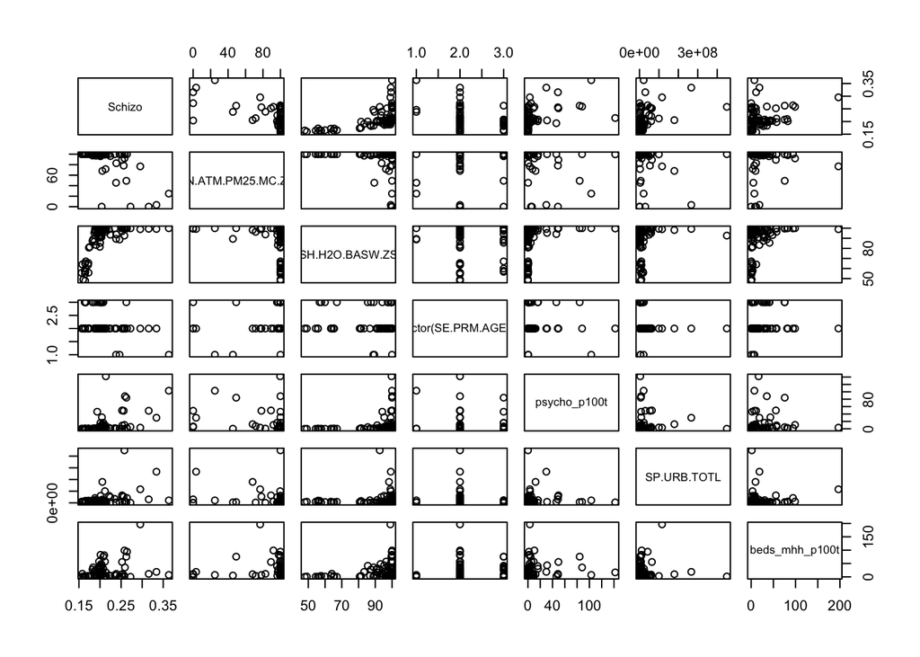

```r
pairs(Schizo ~ EN.ATM.PM25.MC.ZS + SH.H2O.BASW.ZS + factor(SE.PRM.AGES) +
    psycho_p100t + SP.URB.TOTL + beds_mhh_p100t + EN.ATM.PM25.MC.ZS:psycho_p100t, data = df3)
```

6. Outliers

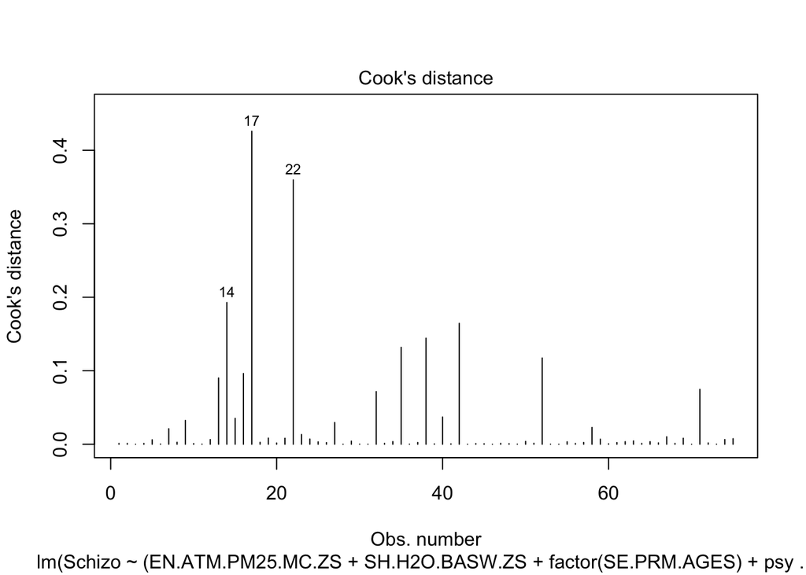

```r
#png("6.outliers.png", units = "in", width = 6, height = 4, res = 300)
plot(model2, which = c(4))
```

```r
#dev.off()
```

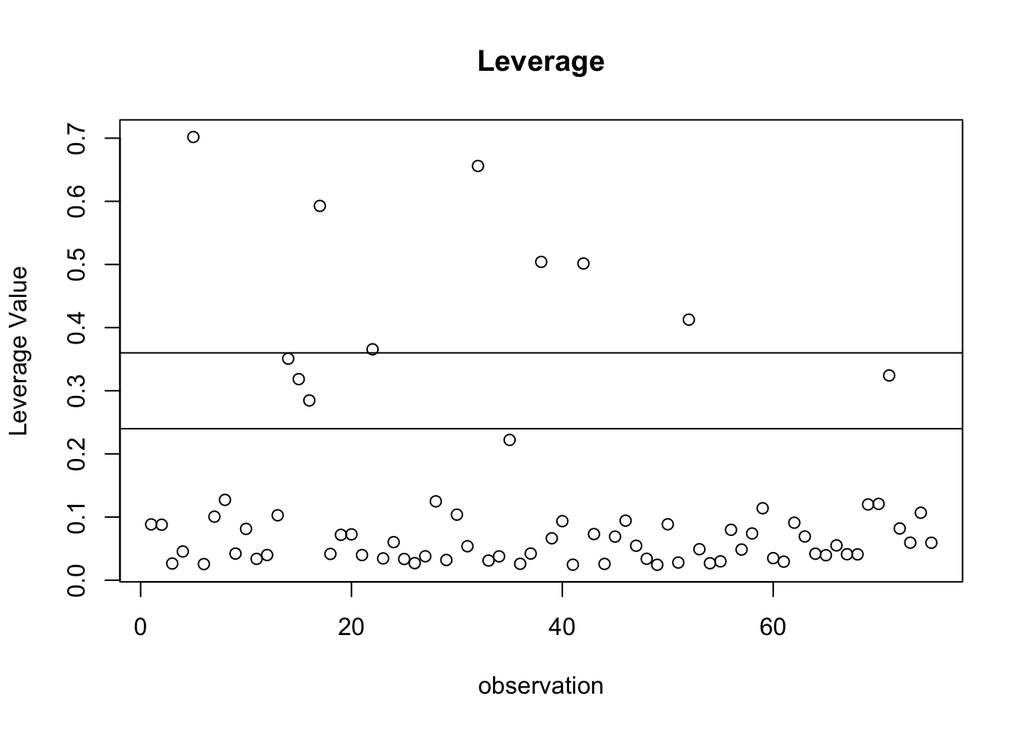

```r
#png("6.leverage.png", units = "in", width = 6, height = 4, res = 300)
lev1=hatvalues(model2)
p = length(coef(model2))
n = nrow(df3)
plot(row.names(model.frame(model2)),lev1, main = "Leverage", xlab="observation", ylab = "Leverage Value")
abline(h = 2 *p/n, lty = 1)
abline(h = 3 *p/n, lty = 1)
```

```r
#dev.off()
```